# Visualisasi_Ecommerce

## Quantity

[interactive chart not shown]

Visualisasi menggunakan Choropleth Map diatas akan menggambarkan total kuantitas produk yang dibeli oleh negara selain United Kingdom. Visualisasi ini menggunakan warna sebagai indikator untuk menentukan total kuantitas terendah dan tertinggi. Visualisasi ini tidak melibatkan Negara UK, karena Negara UK merupakan negara asal perusahaan yang mempunyai total kuantitas sangat banyak dan akan membuat negara lain warnanya menjadi mirip. Hal itu terjadi karena jumlah total kuantitas pada negara lain kecil bila dibandingkan UK. Visualisasi ini bermanfaat bagi divisi pemasaran dan supply perusahaan mampu untuk menentukan strategi pemasaran dan SCM (Supply Chain Management) yang tepat untuk setiap negara berdasarkan total kuantitas produk yang dijual.

Dapat diketahui bahwa semakin tua warna yang terdapat di suatu negara, maka total kuantitas penjualan produknya akan semakin banyak. Dapat diketahui pula bahwa negara Netherlands adalah negara dengan total penjualan terbanyak dari seluruh negara yang menjadi target penjualan perusahaan. Data yang digunakan merupakan data dari Desember 2010 hingga Desember 2011.

## Pendapatan dari Negara

[interactive chart not shown]

Visualisasi menggunakan Bar Chart diatas akan menggambarkan penghasilan perusahaan yang diperoleh di setiap negara (satuan us $). Visualisasi ini menggunakan warna gold sebagai indikator negara yang menghasilkan uang tertinggi, dan ketinggian bar chart sebagai indikator rendah tingginya pendapatan yang dihasilkan perusahan pada setiap negara. Visualisasi ini bermanfaat bagi eksekutif untuk menglihat penghasilan yang telah diperoleh pada setiap negara yang menjadi target penjualan perusahaan. Melalui grafik ini, eksekutif dapat menentukan strategi untuk meningkatkan pendapatan di negara yang dianggap potensial.

Dapat diketahui bahwa Negara UK menghasilkan pendapatan yang terbanyak bagi perusahaan ($6.6 M), disusul oleh Netherland, EIRE, Germany, dan France. Data yang digunakan merupakan data dari Desember 2010 hingga Desember 2011.

## Invoice Unik

[interactive chart not shown]

Visualisasi menggunakan Line Chart diatas akan menggambarkan jumlah pesanan unik yang terjadi pada perusahaan. Visualisasi ini bertujuan agar divisi pemasaran dan supply perusahaan mampu untuk menentukan strategi pemasaran dan SCM (Supply Chain Management) yang tepat untuk setiap bulan berdasarkan jumlah pesanan. Dapat diketahui dari pergerakan line tersebut bahwa Bulan November terdapat kenaikan pesanan unik secara signifikan, sedangkan bulan Desember langsung mengalami penurunan yang tajam. Berdasarkan fakta tersebut, divisi pemasaran dan supply perlu untuk memikirkan strategi untuk memanagemen Demand yang ada agar bisa menghasilkan cost yang optimum dan permintaan kustomer dapat terpenuhi. Data yang digunakan merupakan data dari Desember 2010 hingga Desember 2011.

## Kuantitas Pesanan

[interactive chart not shown]

Visualisasi menggunakan Bar Chart diatas akan menggambarkan jumlah produk berdasarkan kategori produk promosi yang dijual berdasarkan waktu. Terdapat legenda warna biru yang menggambarkan produk tidak gratis, dan merah yang menggambarkan produk gratis (promosi). Visualisasi ini bertujuan untuk mengetahui kapan terdapat produk gratis (unit price = 0) pada perusahaan ini. Manfaat dari visualisasi ini adalah untuk mengetahui pengaruh promosi yang dilakukan terhadap jumlah permintaan dan total penjualan produk. Melalui grafik ini, diharapkan divisi pemasaran dapat memberikan promosi pada waktu yang tepat.

Dapat diketahui dari tinggi Bar chart tersebut bahwa Bulan November terdapat kenaikan produk gratis yang signifikan. Selain itu, terdapat pula peningkatan penjualan produk tidak gratis diatas 600K yang tidak pernah didapatkan pada bulan lainnya. Jadi, diadakannya promosi dapat bepengaruh dengan peningkatan demand. Data yang digunakan merupakan data dari Desember 2010 hingga Desember 2011.

## Frekuensi Banyak Pesanan

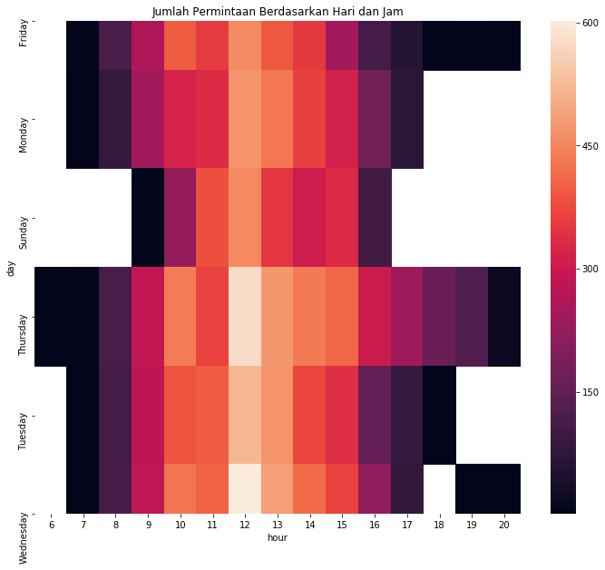